# Project: Investigate a Dataset ( TMDb movie data! )

- Introduction
- Data Wrangling
- Exploratory Data Analysis
- Conclusions

## Introduction

This data set contains information about 10,000 movies collected from The Movie Database (TMDb).In which given data like budget of movie production and revenue.original tile,runtime,popularity,release_year.With the help of this we can analysis and produced good project report using plots.

```python
# This cell to set up import statements for all of the packages that required in Project.

import numpy as np
import pandas as pd
import matplotlib.pyplot as plt
import seaborn as sns
% matplotlib inline
```

## Data Wrangling

```python
# Load and read csv file name 'tmdb-movies.csv'
df_movie =  pd.read_csv('tmdb-movies.csv')
df_movie.head(2)
```

|  | id | imdb_id | popularity | budget | revenue | original_title | cast | homepage | director | tagline | ... | overview | runtime | genres | production_companies | release_date | vote_count | vote_average | release_year | budget_adj | revenue_adj |
| --- | --- | --- | --- | --- | --- | --- | --- | --- | --- | --- | --- | --- | --- | --- | --- | --- | --- | --- | --- | --- | --- |
| 0 | 135397 | tt0369610 | 32.985763 | 150000000 | 1513528810 | Jurassic World | Chris Pratt\|Bryce Dallas Howard\|Irrfan Khan\|Vi... | http://www.jurassicworld.com/ | Colin Trevorrow | The park is open. | ... | Twenty-two years after the events of Jurassic ... | 124 | Action\|Adventure\|Science Fiction\|Thriller | Universal Studios\|Amblin Entertainment\|Legenda... | 6/9/15 | 5562 | 6.5 | 2015 | 1.379999e+08 | 1.392446e+09 |
| 1 | 76341 | tt1392190 | 28.419936 | 150000000 | 378436354 | Mad Max: Fury Road | Tom Hardy\|Charlize Theron\|Hugh Keays-Byrne\|Nic... | http://www.madmaxmovie.com/ | George Miller | What a Lovely Day. | ... | An apocalyptic story set in the furthest reach... | 120 | Action\|Adventure\|Science Fiction\|Thriller | Village Roadshow Pictures\|Kennedy Miller Produ... | 5/13/15 | 6185 | 7.1 | 2015 | 1.379999e+08 | 3.481613e+08 |

2 rows × 21 columns

```python
df_movie.shape
```

```
(10866, 21)
```

```python
print("It's very clear that above given csv file name tmdb-movies have 10866 Row and 21 column")
```

```
It's very clear that above given csv file name tmdb-movies have 10866 Row and 21 column
```

```python
#to know the csv information
df_movie.info()
```

```
<class 'pandas.core.frame.DataFrame'>
RangeIndex: 10866 entries, 0 to 10865
Data columns (total 21 columns):
id                      10866 non-null int64
imdb_id                 10856 non-null object
popularity              10866 non-null float64
budget                  10866 non-null int64
revenue                 10866 non-null int64
original_title          10866 non-null object
cast                    10790 non-null object
homepage                2936 non-null object
director                10822 non-null object
tagline                 8042 non-null object
keywords                9373 non-null object
overview                10862 non-null object
runtime                 10866 non-null int64
genres                  10843 non-null object
production_companies    9836 non-null object
release_date            10866 non-null object
vote_count              10866 non-null int64
vote_average            10866 non-null float64
release_year            10866 non-null int64
budget_adj              10866 non-null float64
revenue_adj             10866 non-null float64
dtypes: float64(4), int64(6), object(11)
memory usage: 1.7+ MB
```

```python
#Find out the null value in given column
df_movie.isnull().sum()
```

```
id                         0
imdb_id                   10
popularity                 0
budget                     0
revenue                    0
original_title             0
cast                      76
homepage                7930
director                  44
tagline                 2824
keywords                1493
overview                   4
runtime                    0
genres                    23
production_companies    1030
release_date               0
vote_count                 0
vote_average               0
release_year               0
budget_adj                 0
revenue_adj                0
dtype: int64
```

```python
# To know the data types in given column
df_movie.dtypes
```

```
id                        int64
imdb_id                  object
popularity              float64
budget                    int64
revenue                   int64
original_title           object
cast                     object
homepage                 object
director                 object
tagline                  object
keywords                 object
overview                 object
runtime                   int64
genres                   object
production_companies     object
release_date             object
vote_count                int64
vote_average            float64
release_year              int64
budget_adj              float64
revenue_adj             float64
dtype: object
```

```python
#change the datatype of 'release_date' object to datetime
df_movie.release_date = pd.to_datetime(df_movie['release_date'])

# To check change of datatype in 'release_date'
df_movie.dtypes
```

```
id                               int64
imdb_id                         object
popularity                     float64
budget                           int64
revenue                          int64
original_title                  object
cast                            object
homepage                        object
director                        object
tagline                         object
keywords                        object
overview                        object
runtime                          int64
genres                          object
production_companies            object
release_date            datetime64[ns]
vote_count                       int64
vote_average                   float64
release_year                     int64
budget_adj                     float64
revenue_adj                    float64
dtype: object
```

```python
df_movie.head(1)
```

|  | id | imdb_id | popularity | budget | revenue | original_title | cast | homepage | director | tagline | ... | overview | runtime | genres | production_companies | release_date | vote_count | vote_average | release_year | budget_adj | revenue_adj |
| --- | --- | --- | --- | --- | --- | --- | --- | --- | --- | --- | --- | --- | --- | --- | --- | --- | --- | --- | --- | --- | --- |
| 0 | 135397 | tt0369610 | 32.985763 | 150000000 | 1513528810 | Jurassic World | Chris Pratt\|Bryce Dallas Howard\|Irrfan Khan\|Vi... | http://www.jurassicworld.com/ | Colin Trevorrow | The park is open. | ... | Twenty-two years after the events of Jurassic ... | 124 | Action\|Adventure\|Science Fiction\|Thriller | Universal Studios\|Amblin Entertainment\|Legenda... | 2015-06-09 | 5562 | 6.5 | 2015 | 1.379999e+08 | 1.392446e+09 |

1 rows × 21 columns

```python
df_movie.describe()
```

|  | id | popularity | budget | revenue | runtime | vote_count | vote_average | release_year | budget_adj | revenue_adj |
| --- | --- | --- | --- | --- | --- | --- | --- | --- | --- | --- |
| count | 10866.000000 | 10866.000000 | 1.086600e+04 | 1.086600e+04 | 10866.000000 | 10866.000000 | 10866.000000 | 10866.000000 | 1.086600e+04 | 1.086600e+04 |
| mean | 66064.177434 | 0.646441 | 1.462570e+07 | 3.982332e+07 | 102.070863 | 217.389748 | 5.974922 | 2001.322658 | 1.755104e+07 | 5.136436e+07 |
| std | 92130.136561 | 1.000185 | 3.091321e+07 | 1.170035e+08 | 31.381405 | 575.619058 | 0.935142 | 12.812941 | 3.430616e+07 | 1.446325e+08 |
| min | 5.000000 | 0.000065 | 0.000000e+00 | 0.000000e+00 | 0.000000 | 10.000000 | 1.500000 | 1960.000000 | 0.000000e+00 | 0.000000e+00 |
| 25% | 10596.250000 | 0.207583 | 0.000000e+00 | 0.000000e+00 | 90.000000 | 17.000000 | 5.400000 | 1995.000000 | 0.000000e+00 | 0.000000e+00 |
| 50% | 20669.000000 | 0.383856 | 0.000000e+00 | 0.000000e+00 | 99.000000 | 38.000000 | 6.000000 | 2006.000000 | 0.000000e+00 | 0.000000e+00 |
| 75% | 75610.000000 | 0.713817 | 1.500000e+07 | 2.400000e+07 | 111.000000 | 145.750000 | 6.600000 | 2011.000000 | 2.085325e+07 | 3.369710e+07 |
| max | 417859.000000 | 32.985763 | 4.250000e+08 | 2.781506e+09 | 900.000000 | 9767.000000 | 9.200000 | 2015.000000 | 4.250000e+08 | 2.827124e+09 |

### Data Cleaning (Cleaning current CSV data remove duplicate, Drop null value and columns and other operations)

```python
# check the dublicate entry in the given data.
sum(df_movie.duplicated())
```

```
1
```

```python
# Delete dublicate Entry
df_movie.drop_duplicates(inplace=True)

# Again check dublicate entry when we remove it's shows zero
sum(df_movie.duplicated())
```

```
0
```

```python
"""
After discussing the structure of the data and any problems that need to be
cleaned. we are removing rows with null values in imdb_id, Cast ,director ,overview ,genres column.
In which we can do analysis on this data.
"""
df_movie.dropna(subset=['imdb_id','cast','director','overview','genres'], inplace=True)
df_movie.info()
```

```
<class 'pandas.core.frame.DataFrame'>
Int64Index: 10724 entries, 0 to 10865
Data columns (total 21 columns):
id                      10724 non-null int64
imdb_id                 10724 non-null object
popularity              10724 non-null float64
budget                  10724 non-null int64
revenue                 10724 non-null int64
original_title          10724 non-null object
cast                    10724 non-null object
homepage                2891 non-null object
director                10724 non-null object
tagline                 7999 non-null object
keywords                9302 non-null object
overview                10724 non-null object
runtime                 10724 non-null int64
genres                  10724 non-null object
production_companies    9770 non-null object
release_date            10724 non-null datetime64[ns]
vote_count              10724 non-null int64
vote_average            10724 non-null float64
release_year            10724 non-null int64
budget_adj              10724 non-null float64
revenue_adj             10724 non-null float64
dtypes: datetime64[ns](1), float64(4), int64(6), object(10)
memory usage: 1.8+ MB
```

```python
# check null entry again
df_movie.isnull().sum()
```

```
id                         0
imdb_id                    0
popularity                 0
budget                     0
revenue                    0
original_title             0
cast                       0
homepage                7833
director                   0
tagline                 2725
keywords                1422
overview                   0
runtime                    0
genres                     0
production_companies     954
release_date               0
vote_count                 0
vote_average               0
release_year               0
budget_adj                 0
revenue_adj                0
dtype: int64
```

```python
df_movie.head(2)
```

|  | id | imdb_id | popularity | budget | revenue | original_title | cast | homepage | director | tagline | ... | overview | runtime | genres | production_companies | release_date | vote_count | vote_average | release_year | budget_adj | revenue_adj |
| --- | --- | --- | --- | --- | --- | --- | --- | --- | --- | --- | --- | --- | --- | --- | --- | --- | --- | --- | --- | --- | --- |
| 0 | 135397 | tt0369610 | 32.985763 | 150000000 | 1513528810 | Jurassic World | Chris Pratt\|Bryce Dallas Howard\|Irrfan Khan\|Vi... | http://www.jurassicworld.com/ | Colin Trevorrow | The park is open. | ... | Twenty-two years after the events of Jurassic ... | 124 | Action\|Adventure\|Science Fiction\|Thriller | Universal Studios\|Amblin Entertainment\|Legenda... | 2015-06-09 | 5562 | 6.5 | 2015 | 1.379999e+08 | 1.392446e+09 |
| 1 | 76341 | tt1392190 | 28.419936 | 150000000 | 378436354 | Mad Max: Fury Road | Tom Hardy\|Charlize Theron\|Hugh Keays-Byrne\|Nic... | http://www.madmaxmovie.com/ | George Miller | What a Lovely Day. | ... | An apocalyptic story set in the furthest reach... | 120 | Action\|Adventure\|Science Fiction\|Thriller | Village Roadshow Pictures\|Kennedy Miller Produ... | 2015-05-13 | 6185 | 7.1 | 2015 | 1.379999e+08 | 3.481613e+08 |

2 rows × 21 columns

```python
#Drop four column 'homepage,keywords,budget_adj and revenue_adj'.
#these column no need to be in our analysis that's why we drop it
df_movie.drop(['homepage', 'keywords', 'budget_adj', 'revenue_adj'], axis=1, inplace=True)
df_movie.info()
```

```
<class 'pandas.core.frame.DataFrame'>
Int64Index: 10724 entries, 0 to 10865
Data columns (total 17 columns):
id                      10724 non-null int64
imdb_id                 10724 non-null object
popularity              10724 non-null float64
budget                  10724 non-null int64
revenue                 10724 non-null int64
original_title          10724 non-null object
cast                    10724 non-null object
director                10724 non-null object
tagline                 7999 non-null object
overview                10724 non-null object
runtime                 10724 non-null int64
genres                  10724 non-null object
production_companies    9770 non-null object
release_date            10724 non-null datetime64[ns]
vote_count              10724 non-null int64
vote_average            10724 non-null float64
release_year            10724 non-null int64
dtypes: datetime64[ns](1), float64(2), int64(6), object(8)
memory usage: 1.5+ MB
```

```python
# To know the data types in given column
df_movie.dtypes
```

```
id                               int64
imdb_id                         object
popularity                     float64
budget                           int64
revenue                          int64
original_title                  object
cast                            object
director                        object
tagline                         object
overview                        object
runtime                          int64
genres                          object
production_companies            object
release_date            datetime64[ns]
vote_count                       int64
vote_average                   float64
release_year                     int64
dtype: object
```

```python
#change the datatype of 'release_date' object to datetime
df_movie.release_date = pd.to_datetime(df_movie['release_date'])
df_movie.dtypes
```

```
id                               int64
imdb_id                         object
popularity                     float64
budget                           int64
revenue                          int64
original_title                  object
cast                            object
director                        object
tagline                         object
overview                        object
runtime                          int64
genres                          object
production_companies            object
release_date            datetime64[ns]
vote_count                       int64
vote_average                   float64
release_year                     int64
dtype: object
```

```python
""" Using Insert function with the help of budget and revenue column.
we get profit column for further analysis."""
df_movie.insert(5,'profit',df_movie['revenue']-df_movie['budget'])
```

```python
df_movie.head(1)
```

|  | id | imdb_id | popularity | budget | revenue | profit | original_title | cast | director | tagline | overview | runtime | genres | production_companies | release_date | vote_count | vote_average | release_year |
| --- | --- | --- | --- | --- | --- | --- | --- | --- | --- | --- | --- | --- | --- | --- | --- | --- | --- | --- |
| 0 | 135397 | tt0369610 | 32.985763 | 150000000 | 1513528810 | 1363528810 | Jurassic World | Chris Pratt\|Bryce Dallas Howard\|Irrfan Khan\|Vi... | Colin Trevorrow | The park is open. | Twenty-two years after the events of Jurassic ... | 124 | Action\|Adventure\|Science Fiction\|Thriller | Universal Studios\|Amblin Entertainment\|Legenda... | 2015-06-09 | 5562 | 6.5 | 2015 |

```python
""" To find the mean, standard deviation, min & max 25%,50% & 75% desired column"""
df_movie.describe()
```

|  | id | popularity | budget | revenue | profit | runtime | vote_count | vote_average | release_year |
| --- | --- | --- | --- | --- | --- | --- | --- | --- | --- |
| count | 10724.000000 | 10724.000000 | 1.072400e+04 | 1.072400e+04 | 1.072400e+04 | 10724.000000 | 10724.000000 | 10724.000000 | 10724.000000 |
| mean | 65184.471559 | 0.652858 | 1.481331e+07 | 4.034621e+07 | 2.553290e+07 | 102.503450 | 219.943305 | 5.964407 | 2001.254196 |
| std | 91474.417621 | 1.005072 | 3.107239e+07 | 1.176863e+08 | 9.718023e+07 | 30.460109 | 578.981655 | 0.930163 | 12.822467 |
| min | 5.000000 | 0.000188 | 0.000000e+00 | 0.000000e+00 | -4.139124e+08 | 0.000000 | 10.000000 | 1.500000 | 1960.000000 |
| 25% | 10545.750000 | 0.210766 | 0.000000e+00 | 0.000000e+00 | 0.000000e+00 | 90.000000 | 17.000000 | 5.400000 | 1995.000000 |
| 50% | 20307.500000 | 0.387247 | 0.000000e+00 | 0.000000e+00 | 0.000000e+00 | 99.000000 | 39.000000 | 6.000000 | 2006.000000 |
| 75% | 73937.500000 | 0.721577 | 1.600000e+07 | 2.500980e+07 | 1.000000e+07 | 112.000000 | 148.250000 | 6.600000 | 2011.000000 |
| max | 417859.000000 | 32.985763 | 4.250000e+08 | 2.781506e+09 | 2.544506e+09 | 900.000000 | 9767.000000 | 9.200000 | 2015.000000 |

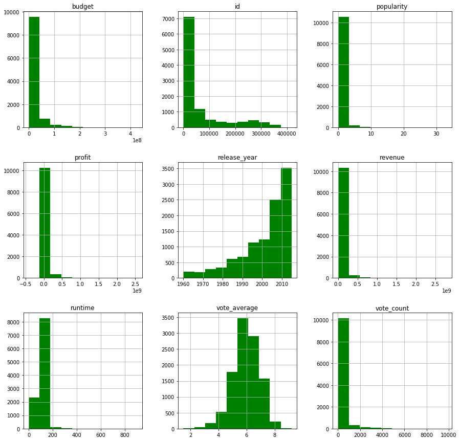

```python
df_movie.hist(figsize = (15,15),color = 'green');
```

## Exploratory Data Analysis

### Research Question 1 ( Most profitable release year between 1960 to 2015 )

```python
#we want to know the profitable of movies for every year
#therefore we have to sum up all the movies of a particular year

most_profitable_year = df_movie.groupby('release_year')['profit'].sum()
print(most_profitable_year)
```

```
release_year
1960      122948052
1961      291583188
1962      160857720
1963      114073489
1964      301498621
1965      387876739
1966       27181889
1967      637182637
1968      192793980
1969      201827989
1970      433260023
1971      328913610
1972      458450917
1973     1158790319
```

[output cut: 43 more lines]

```python
# To find which year made the highest and lowest profit ?
most_profitable_year.idxmax(),most_profitable_year.idxmin()

# According to data year 2015 is most profitale release year of movies and
# year 1966 is most non profitable release year"""
```

```
(2015, 1966)
```

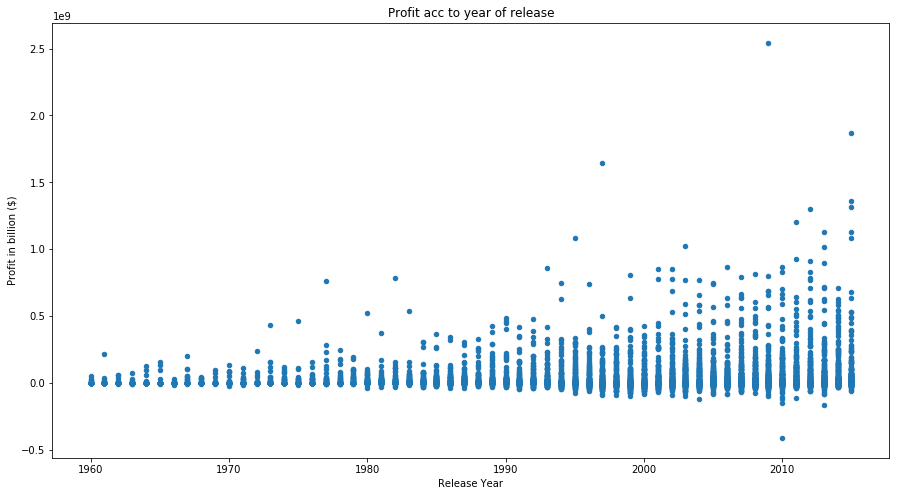

```python
df_movie.plot(x ='release_year',y ='profit',kind='scatter',figsize=(15,8));
plt.ylabel('Profit in billion ($)');
plt.xlabel('Release Year');
plt.title('Profit acc to year of release');
```

> **observation** : According to movies data year 2015 is most profitale release year and year 1966 is most non profitable release year.In 1966 all movies only generate 27181889 profit which is very low as we analysis the data and in 2015 all released movies generate 19165902961 profit which is maximum in all above data.

### Research Question 2 (How many movies release in a year?)

```python
# Number of movies produced each year
release_per_year= df_movie['release_year'].value_counts().sort_index();
release_per_year
```

```
1960     32
1961     31
1962     32
1963     34
1964     42
1965     35
1966     46
1967     38
1968     38
1969     30
1970     40
1971     55
1972     40
1973     55
1974     46
```

[output cut: 42 more lines]

```
(2014, 1969)
```

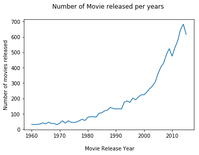

```python
plt.plot(release_per_year);
plt.title('Number of Movie released per years \n');
plt.xlabel('\n Movie Release Year');
plt.ylabel('Number of movies released');
# release Years with maximum and minimum movie released
release_per_year.idxmax() , release_per_year.idxmin()
```

> **observation** : In every year number of movies release year in 1960 only 32 movies released and in 2015 number of movies released 617.when we calculated max and min we find that in year 1969 minimum only 30 movies realesed and year 2014 maximum movies released 682.when we analysis the plot graph as shown very clear that the graph is moved dramitically upwards direction as passed releasing years.

### Research Question 3 (Top 10 most profitable and non profitable movies inbetween 1960 to 2015)

```python
# 01. Top ten most profitable movie all the years 1960 to 2015
profit_sort = df_movie['profit'].sort_values(ascending=False)[:10]

most_profitable=pd.DataFrame()
titles=[]
profit=[]
for i in profit_sort.index:
    titles.append(df_movie.loc[i,'original_title'])
    profit.append(profit_sort.loc[i])
most_profitable['Movies Titles']=titles
most_profitable['Profit']=profit
most_profitable.set_index('Movies Titles',inplace=True)
print(most_profitable)
```

```
                                                  Profit
Movies Titles
Avatar                                        2544505847
Star Wars: The Force Awakens                  1868178225
Titanic                                       1645034188
Jurassic World                                1363528810
Furious 7                                     1316249360
The Avengers                                  1299557910
Harry Potter and the Deathly Hallows: Part 2  1202817822
Avengers: Age of Ultron                       1125035767
Frozen                                        1124219009
The Net                                       1084279658
```

```python
# 02. Top ten Non-profitable movie all the years 1960 to 2015
loss_sort = df_movie['profit'].sort_values(ascending=True)[:10]

non_profitable=pd.DataFrame()
titles=[]
profit=[]
for i in loss_sort.index:
    titles.append(df_movie.loc[i,'original_title'])
    profit.append(loss_sort.loc[i])
non_profitable['Movies Titles']=titles
non_profitable['Non Profit']=profit
non_profitable.set_index('Movies Titles',inplace=True)
print(non_profitable)
```

```
                      Non Profit
Movies Titles
The Warrior's Way     -413912431
The Lone Ranger       -165710090
The Wolfman           -150000000
The Pacific           -120000000
The Alamo             -119180039
Mars Needs Moms       -111007242
Double Wedding        -104002432
Dragonball Evolution  -100000000
Brother Bear           -99999750
The 13th Warrior       -98301101
```

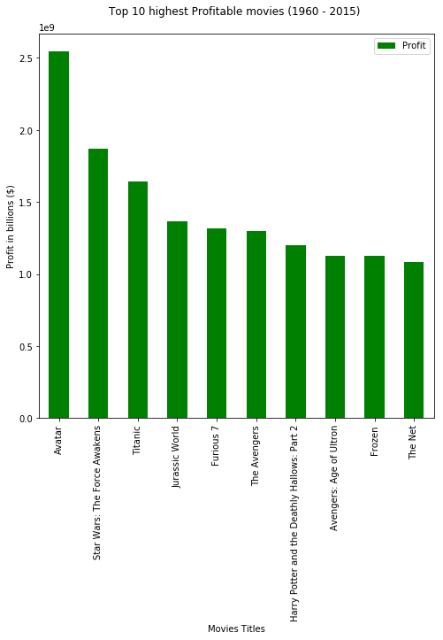

```python
# plot show clearly the most profitable top ten movies
most_profitable.plot(kind ='bar',figsize=(8,8),color = 'green')
plt.title('Top 10 highest Profitable movies (1960 - 2015) \n');
plt.ylabel('Profit in billions ($)');
```

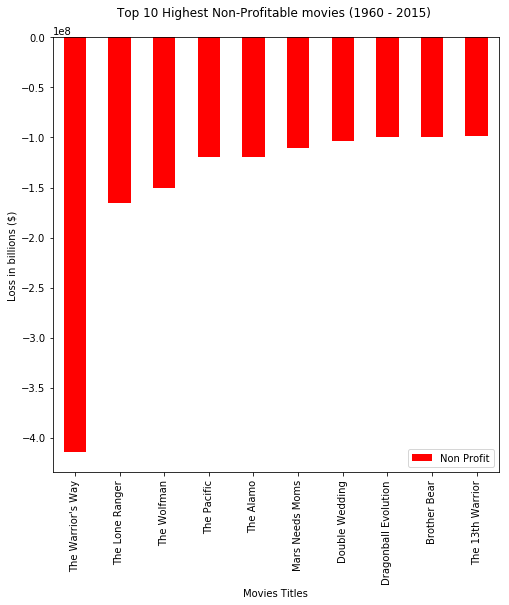

```python
# plot show clearly the most profitable top ten movies
non_profitable.plot(kind ='bar',figsize=(8,8), color = 'red')
plt.title('Top 10 Highest Non-Profitable movies (1960 - 2015) \n');
plt.ylabel('Loss in billions ($)');
```

> **observation** : Both profit and loss clearly shown in data top 10 year in between 1960 to 2015.In graph clearly shown the profit and loss which graph is downwards side is loss show and upwards direction bar graph show profit

### Research Question 4 (which movie earn maximum and minimum profit in between 1960 to 2015 ?)

```python
# make a function name max_min in which can help out to find the max and min value of column enter value
def max_min(column):
    #for maximum value
    max_value = df_movie[column].idxmax()
    maximum_value = pd.DataFrame(df_movie.loc[max_value])

    #for minimum value
    min_value = df_movie[column].idxmin()
    minimum_value = pd.DataFrame(df_movie.loc[min_value])

    #Both max and min value in one place
    info = pd.concat([maximum_value , minimum_value ], axis=1)

    return info

#for profit max and min
max_min('profit')
```

|  | 1386 | 2244 |
| --- | --- | --- |
| id | 19995 | 46528 |
| imdb_id | tt0499549 | tt1032751 |
| popularity | 9.43277 | 0.25054 |
| budget | 237000000 | 425000000 |
| revenue | 2781505847 | 11087569 |
| profit | 2544505847 | -413912431 |
| original_title | Avatar | The Warrior's Way |
| cast | Sam Worthington\|Zoe Saldana\|Sigourney Weaver\|S... | Kate Bosworth\|Jang Dong-gun\|Geoffrey Rush\|Dann... |
| director | James Cameron | Sngmoo Lee |
| tagline | Enter the World of Pandora. | Assassin. Hero. Legend. |
| overview | In the 22nd century, a paraplegic Marine is di... | An Asian assassin (Dong-gun Jang) is forced to... |
| runtime | 162 | 100 |
| genres | Action\|Adventure\|Fantasy\|Science Fiction | Adventure\|Fantasy\|Action\|Western\|Thriller |
| production_companies | Ingenious Film Partners\|Twentieth Century Fox ... | Boram Entertainment Inc. |
| release_date | 2009-12-10 00:00:00 | 2010-12-02 00:00:00 |
| vote_count | 8458 | 74 |
| vote_average | 7.1 | 6.4 |
| release_year | 2009 | 2010 |

> **observation** : In the above data we find top ten high and non profitable movie all the years 1960 to 2015. MOst proitable movie **'Avatar'** with budget 237000000 have 2544505847 profit most protabile movie all time release year 2009.On the other hand non profitable movie of all time is **'The Warrior's Way'** with budget 425000000 have loss 413912431 release year 2010.

### Research Question 5 (Which top 10 movies is Highest in budget and revenue ? )

```python
# using .nlargest function to get top 10 highest budget
high_budget=df_movie.nlargest(10, 'budget', keep='first')
high_budget
```

|  | id | imdb_id | popularity | budget | revenue | profit | original_title | cast | director | tagline | overview | runtime | genres | production_companies | release_date | vote_count | vote_average | release_year |
| --- | --- | --- | --- | --- | --- | --- | --- | --- | --- | --- | --- | --- | --- | --- | --- | --- | --- | --- |
| 2244 | 46528 | tt1032751 | 0.250540 | 425000000 | 11087569 | -413912431 | The Warrior's Way | Kate Bosworth\|Jang Dong-gun\|Geoffrey Rush\|Dann... | Sngmoo Lee | Assassin. Hero. Legend. | An Asian assassin (Dong-gun Jang) is forced to... | 100 | Adventure\|Fantasy\|Action\|Western\|Thriller | Boram Entertainment Inc. | 2010-12-02 | 74 | 6.4 | 2010 |
| 3375 | 1865 | tt1298650 | 4.955130 | 380000000 | 1021683000 | 641683000 | Pirates of the Caribbean: On Stranger Tides | Johnny Depp\|PenÃ©lope Cruz\|Geoffrey Rush\|Ian M... | Rob Marshall | Live Forever Or Die Trying. | Captain Jack Sparrow crosses paths with a woma... | 136 | Adventure\|Action\|Fantasy | Walt Disney Pictures\|Jerry Bruckheimer Films\|M... | 2011-05-11 | 3180 | 6.3 | 2011 |
| 7387 | 285 | tt0449088 | 4.965391 | 300000000 | 961000000 | 661000000 | Pirates of the Caribbean: At World's End | Johnny Depp\|Orlando Bloom\|Keira Knightley\|Geof... | Gore Verbinski | At the end of the world, the adventure begins. | Captain Barbossa, long believed to be dead, ha... | 169 | Adventure\|Fantasy\|Action | Walt Disney Pictures\|Jerry Bruckheimer Films\|S... | 2007-05-19 | 2626 | 6.8 | 2007 |
| 14 | 99861 | tt2395427 | 5.944927 | 280000000 | 1405035767 | 1125035767 | Avengers: Age of Ultron | Robert Downey Jr.\|Chris Hemsworth\|Mark Ruffalo... | Joss Whedon | A New Age Has Come. | When Tony Stark tries to jumpstart a dormant p... | 141 | Action\|Adventure\|Science Fiction | Marvel Studios\|Prime Focus\|Revolution Sun Studios | 2015-04-22 | 4304 | 7.4 | 2015 |
| 6570 | 1452 | tt0348150 | 1.957331 | 270000000 | 391081192 | 121081192 | Superman Returns | Brandon Routh\|Kevin Spacey\|Kate Bosworth\|James... | Bryan Singer | NaN | Set 5 years after the end of Superman II, the ... | 154 | Adventure\|Fantasy\|Action\|Science Fiction | DC Comics\|Legendary Pictures\|Warner Bros.\|Bad ... | 2006-06-28 | 834 | 5.3 | 2006 |
| 1929 | 38757 | tt0398286 | 2.865684 | 260000000 | 591794936 | 331794936 | Tangled | Zachary Levi\|Mandy Moore\|Donna Murphy\|Ron Perl... | Nathan Greno\|Byron Howard | They're taking adventure to new lengths. | When the kingdom's most wanted-and most charmi... | 100 | Animation\|Family | Walt Disney Pictures\|Walt Disney Animation Stu... | 2010-11-24 | 2019 | 7.3 | 2010 |
| 4411 | 49529 | tt0401729 | 1.588457 | 260000000 | 284139100 | 24139100 | John Carter | Taylor Kitsch\|Lynn Collins\|Mark Strong\|Willem ... | Andrew Stanton | Lost in Our World. Found in Another. | Civil War vet John Carter is transplanted to M... | 132 | Action\|Adventure\|Fantasy\|Science Fiction | Walt Disney Pictures | 2012-03-07 | 1479 | 6.0 | 2012 |
| 7394 | 559 | tt0413300 | 2.520912 | 258000000 | 890871626 | 632871626 | Spider-Man 3 | Tobey Maguire\|Kirsten Dunst\|James Franco\|Thoma... | Sam Raimi | The battle within. | The seemingly invincible Spider-Man goes up ag... | 139 | Fantasy\|Action\|Adventure | Columbia Pictures\|Laura Ziskin Productions\|Mar... | 2007-05-01 | 2083 | 5.8 | 2007 |
| 5508 | 57201 | tt1210819 | 1.214510 | 255000000 | 89289910 | -165710090 | The Lone Ranger | Johnny Depp\|Armie Hammer\|William Fichtner\|Hele... | Gore Verbinski | Never Take Off the Mask | The Texas Rangers chase down a gang of outlaws... | 149 | Action\|Adventure\|Western | Walt Disney Pictures\|Jerry Bruckheimer Films\|I... | 2013-07-03 | 1607 | 6.0 | 2013 |
| 634 | 122917 | tt2310332 | 10.174599 | 250000000 | 955119788 | 705119788 | The Hobbit: The Battle of the Five Armies | Martin Freeman\|Ian McKellen\|Richard Armitage\|K... | Peter Jackson | Witness the defining chapter of the Middle-Ear... | Immediately after the events of The Desolation... | 144 | Adventure\|Fantasy | WingNut Films\|New Line Cinema\|3Foot7\|Metro-Gol... | 2014-12-10 | 3110 | 7.1 | 2014 |

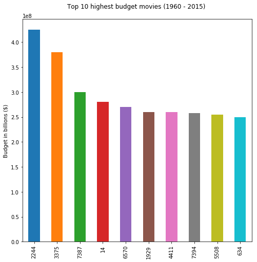

```python
# plot show clearly the most profitable top ten movies
high_budget['budget'].plot(kind ='bar',figsize=(8,8))
plt.title('Top 10 highest budget movies (1960 - 2015) \n');
plt.ylabel('Budget in billions ($)');
```

```python
# using .nlargest function to get top 10 highest revenue
high_revenue=df_movie.nlargest(10, 'revenue', keep='first')
high_revenue
```

|  | id | imdb_id | popularity | budget | revenue | profit | original_title | cast | director | tagline | overview | runtime | genres | production_companies | release_date | vote_count | vote_average | release_year |
| --- | --- | --- | --- | --- | --- | --- | --- | --- | --- | --- | --- | --- | --- | --- | --- | --- | --- | --- |
| 1386 | 19995 | tt0499549 | 9.432768 | 237000000 | 2781505847 | 2544505847 | Avatar | Sam Worthington\|Zoe Saldana\|Sigourney Weaver\|S... | James Cameron | Enter the World of Pandora. | In the 22nd century, a paraplegic Marine is di... | 162 | Action\|Adventure\|Fantasy\|Science Fiction | Ingenious Film Partners\|Twentieth Century Fox ... | 2009-12-10 | 8458 | 7.1 | 2009 |
| 3 | 140607 | tt2488496 | 11.173104 | 200000000 | 2068178225 | 1868178225 | Star Wars: The Force Awakens | Harrison Ford\|Mark Hamill\|Carrie Fisher\|Adam D... | J.J. Abrams | Every generation has a story. | Thirty years after defeating the Galactic Empi... | 136 | Action\|Adventure\|Science Fiction\|Fantasy | Lucasfilm\|Truenorth Productions\|Bad Robot | 2015-12-15 | 5292 | 7.5 | 2015 |
| 5231 | 597 | tt0120338 | 4.355219 | 200000000 | 1845034188 | 1645034188 | Titanic | Kate Winslet\|Leonardo DiCaprio\|Frances Fisher\|... | James Cameron | Nothing on Earth could come between them. | 84 years later, a 101-year-old woman named Ros... | 194 | Drama\|Romance\|Thriller | Paramount Pictures\|Twentieth Century Fox Film ... | 1997-11-18 | 4654 | 7.3 | 1997 |
| 4361 | 24428 | tt0848228 | 7.637767 | 220000000 | 1519557910 | 1299557910 | The Avengers | Robert Downey Jr.\|Chris Evans\|Mark Ruffalo\|Chr... | Joss Whedon | Some assembly required. | When an unexpected enemy emerges and threatens... | 143 | Science Fiction\|Action\|Adventure | Marvel Studios | 2012-04-25 | 8903 | 7.3 | 2012 |
| 0 | 135397 | tt0369610 | 32.985763 | 150000000 | 1513528810 | 1363528810 | Jurassic World | Chris Pratt\|Bryce Dallas Howard\|Irrfan Khan\|Vi... | Colin Trevorrow | The park is open. | Twenty-two years after the events of Jurassic ... | 124 | Action\|Adventure\|Science Fiction\|Thriller | Universal Studios\|Amblin Entertainment\|Legenda... | 2015-06-09 | 5562 | 6.5 | 2015 |
| 4 | 168259 | tt2820852 | 9.335014 | 190000000 | 1506249360 | 1316249360 | Furious 7 | Vin Diesel\|Paul Walker\|Jason Statham\|Michelle ... | James Wan | Vengeance Hits Home | Deckard Shaw seeks revenge against Dominic Tor... | 137 | Action\|Crime\|Thriller | Universal Pictures\|Original Film\|Media Rights ... | 2015-04-01 | 2947 | 7.3 | 2015 |
| 14 | 99861 | tt2395427 | 5.944927 | 280000000 | 1405035767 | 1125035767 | Avengers: Age of Ultron | Robert Downey Jr.\|Chris Hemsworth\|Mark Ruffalo... | Joss Whedon | A New Age Has Come. | When Tony Stark tries to jumpstart a dormant p... | 141 | Action\|Adventure\|Science Fiction | Marvel Studios\|Prime Focus\|Revolution Sun Studios | 2015-04-22 | 4304 | 7.4 | 2015 |
| 3374 | 12445 | tt1201607 | 5.711315 | 125000000 | 1327817822 | 1202817822 | Harry Potter and the Deathly Hallows: Part 2 | Daniel Radcliffe\|Rupert Grint\|Emma Watson\|Alan... | David Yates | It all ends here. | Harry, Ron and Hermione continue their quest t... | 130 | Adventure\|Family\|Fantasy | Warner Bros.\|Heyday Films\|Moving Picture Compa... | 2011-07-07 | 3750 | 7.7 | 2011 |
| 5422 | 109445 | tt2294629 | 6.112766 | 150000000 | 1274219009 | 1124219009 | Frozen | Kristen Bell\|Idina Menzel\|Jonathan Groff\|Josh ... | Chris Buck\|Jennifer Lee | Only the act of true love will thaw a frozen h... | Young princess Anna of Arendelle dreams about ... | 102 | Animation\|Adventure\|Family | Walt Disney Pictures\|Walt Disney Animation Stu... | 2013-11-27 | 3369 | 7.5 | 2013 |
| 5425 | 68721 | tt1300854 | 4.946136 | 200000000 | 1215439994 | 1015439994 | Iron Man 3 | Robert Downey Jr.\|Gwyneth Paltrow\|Guy Pearce\|D... | Shane Black | Unleash the power behind the armor. | When Tony Stark's world is torn apart by a for... | 130 | Action\|Adventure\|Science Fiction | Marvel Studios | 2013-04-18 | 6882 | 6.9 | 2013 |

[figure not shown]

```python
# plot show clearly the most profitable top ten movies
high_revenue['revenue'].plot(kind ='bar',figsize=(8,8))
plt.title('Top 10 highest budget movies (1960 - 2015) \n');
plt.ylabel('Budget in billions ($)');
```

> **observation** : **In the above interpretation we use .nlarget function**

> **Highest Revenue**: In above query we found top ten highest revenue movies in which first position movie name **'Avatar'** with generate revenue 2781505847 and tenth position movie was **'Iron Man 3'** with genertae revenue 1215439994.

### Research Question 6 ( How runtime plays important role in revenue,profit,and popularity? )

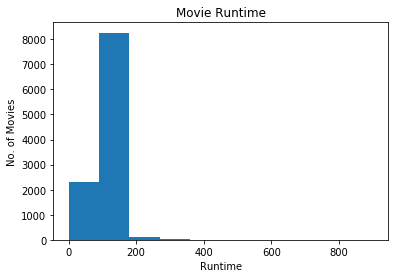

```python
# draw a histogram graph of run time
plt.hist(df_movie['runtime'])
#displays the plot
plt.title('Movie Runtime')
plt.xlabel('Runtime')
plt.ylabel('No. of Movies')
plt.show()
```

```python
df_movie.runtime.describe()
```

```
count    10724.000000
mean       102.503450
std         30.460109
min          0.000000
25%         90.000000
50%         99.000000
75%        112.000000
max        900.000000
Name: runtime, dtype: float64
```

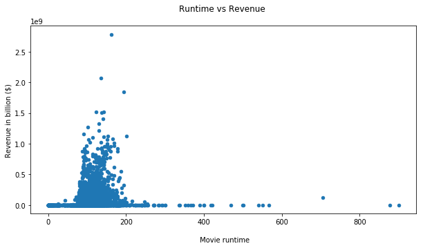

```python
df_movie.plot(x='runtime',y='revenue',kind='scatter',figsize=(10,5));
plt.xlabel('\n Movie runtime');
plt.ylabel('Revenue in billion ($)');
plt.title('Runtime vs Revenue \n');
```

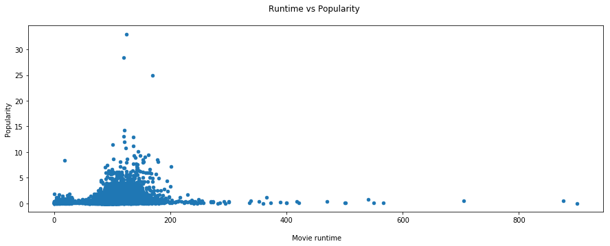

```python
df_movie.plot(x='runtime',y='popularity',kind='scatter',figsize=(15,5));
plt.xlabel('\n Movie runtime');
plt.ylabel('Popularity');
plt.title('Runtime vs Popularity \n');
```

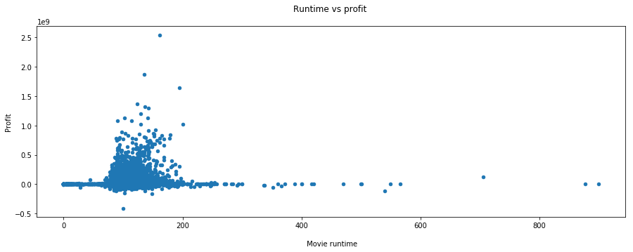

```python
df_movie.plot(x='runtime',y='profit',kind='scatter',figsize=(15,5));
plt.xlabel('\n Movie runtime');
plt.ylabel('Profit');
plt.title('Runtime vs profit \n');
```

```python
# To anlaysis the max and min runtime value and movie name
max_min('runtime')
```

|  | 3894 | 92 |
| --- | --- | --- |
| id | 125336 | 370687 |
| imdb_id | tt2044056 | tt3608646 |
| popularity | 0.006925 | 1.87604 |
| budget | 0 | 0 |
| revenue | 0 | 0 |
| profit | 0 | 0 |
| original_title | The Story of Film: An Odyssey | Mythica: The Necromancer |
| cast | Mark Cousins\|Jean-Michel Frodon\|Cari Beauchamp... | Melanie Stone\|Adam Johnson\|Kevin Sorbo\|Nicola ... |
| director | Mark Cousins | A. Todd Smith |
| tagline | NaN | NaN |
| overview | The Story of Film: An Odyssey, written and dir... | Mallister takes Thane prisoner and forces Mare... |
| runtime | 900 | 0 |
| genres | Documentary | Fantasy\|Action\|Adventure |
| production_companies | NaN | Arrowstorm Entertainment\|Camera 40 Productions... |
| release_date | 2011-09-03 00:00:00 | 2015-12-19 00:00:00 |
| vote_count | 14 | 11 |
| vote_average | 9.2 | 5.4 |
| release_year | 2011 | 2015 |

> **03.** **maximum runtime 900.00 Min** movie name **'The Story of Film: An Odyssey'** It is a documentary divided to 15 episodes of 60 Min each.which does not show any impact in popularity and profit.

## Conclusions

> I have referred to pandas.pydata.org,Stack Overflow for help to complete the analysis.

> **I used both For loop and.nlargest function.they both have different way to show analysis.**

> **Thank you.**

```python
df_movie.to_csv('tmdb-movies_edited.csv', index=False)
```